# MD5

Author

Kamran Acito

```r
library(tidyr)
library(tidyverse)
library(dplyr)
```

```r
twitch_data <- read_csv("https://raw.githubusercontent.com/vaiseys/dav-course/main/Data/twitchdata-update.csv")
```

```r
library(janitor)
twitch_data <- clean_names(twitch_data)

# Inspect new names
colnames(twitch_data)
```

```
 [1] "channel"             "watch_time_minutes"  "stream_time_minutes"
 [4] "peak_viewers"        "average_viewers"     "followers"
 [7] "followers_gained"    "views_gained"        "partnered"
[10] "mature"              "language"
```

## Question 1

```r
five_random <- twitch_data |>
  sample_n(size = 5) |>
  select(channel, average_viewers, followers)
five_random
```

```
# A tibble: 5 × 3
  channel   average_viewers followers
  <chr>               <dbl>     <dbl>
1 Aydan                3507   1701314
2 TeePee               4410    520519
3 AladdinTV            1416    110211
4 GingiTV              1713    156597
5 FEDMYSTER            9086    609723
```

```r
summary_twovariables <- twitch_data |>
  select(channel, average_viewers, followers)

summary(summary_twovariables)
```

```
   channel          average_viewers    followers
 Length:1000        Min.   :   235   Min.   :   3660
 Class :character   1st Qu.:  1458   1st Qu.: 170546
 Mode  :character   Median :  2425   Median : 318063
                    Mean   :  4781   Mean   : 570054
                    3rd Qu.:  4786   3rd Qu.: 624332
                    Max.   :147643   Max.   :8938903
```

I notice from this data that the means and medians are much smaller values compared to the maximum values for both variables. This indicates that there are strong outliers in the data. The distribution is definitely skewed because the mean is higher than the median.

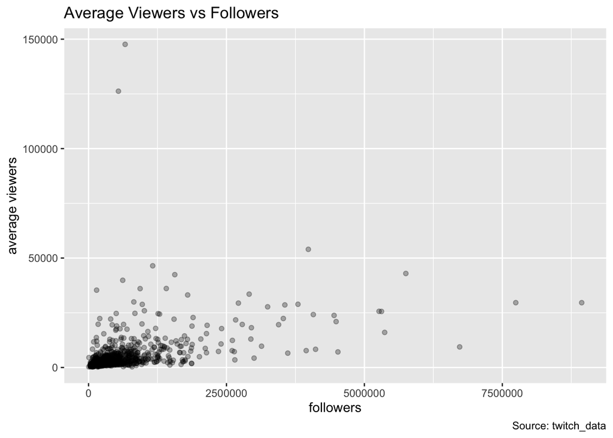

```r
ggplot(data = twitch_data,
       mapping = aes(x = followers,
                     y = average_viewers)) +
  geom_jitter(alpha = 0.3) +
  labs(title = "Average Viewers vs Followers", caption = "Source: twitch_data", x = "followers", y = "average viewers")
```

This scatterplot has most of the data points concentrated around the origin. Most outliers are streamers with many followers but there are 2 outliers who have high amounts of average viewers but a low follower count.

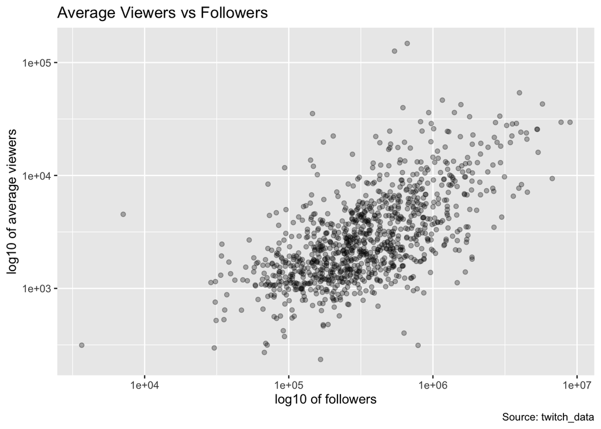

```r
ggplot(twitch_data,
       mapping = aes(x = followers,
                     y = average_viewers)) +
  geom_jitter(alpha = 0.3) +
  labs(title = "Average Viewers vs Followers", caption = "Source: twitch_data", x = "log10 of followers", y = "log10 of average viewers") +
  scale_x_log10() +
  scale_y_log10()
```

After adding scale_x_log10 and scale_y_log10, the data is easier to visualize. There is now a visible positive relationship between followers and average viewers.

```r
twitch_data <- twitch_data %>%
  mutate(log_viewers = log10(average_viewers),
         log_followers = log10(followers))
```

## Question 2

```r
fit1 <- lm(log_viewers ~ log_followers,
           data = twitch_data)

broom::tidy(fit1)
```

```
# A tibble: 2 × 5
  term          estimate std.error statistic   p.value
  <chr>            <dbl>     <dbl>     <dbl>     <dbl>
1 (Intercept)      0.198    0.125       1.58 1.15e-  1
2 log_followers    0.588    0.0226     26.0  1.69e-114
```

```r
fit1
```

```
Call:
lm(formula = log_viewers ~ log_followers, data = twitch_data)

Coefficients:
  (Intercept)  log_followers
       0.1978         0.5885
```

$$1.1^{0.59} = 1.0578 $$

This means that a 10% increase in followers is associated with a 5.9% increase in the average number of viewers.

## Question 3

```r
library(broom)

pred_data <- augment(fit1)

# glimpse our new data
glimpse(pred_data)
```

```
Rows: 1,000
Columns: 8
$ log_viewers   <dbl> 4.442731, 4.408410, 4.040444, 3.887280, 4.471321, 4.6275…
$ log_followers <dbl> 6.511388, 6.725108, 6.247393, 6.596030, 6.951284, 6.1940…
$ .fitted       <dbl> 4.029761, 4.155534, 3.874400, 4.079572, 4.288638, 3.8430…
$ .resid        <dbl> 0.4129697, 0.2528757, 0.1660436, -0.1922928, 0.1826833, …
$ .hat          <dbl> 0.006194481, 0.008694557, 0.003782169, 0.007126066, 0.01…
$ .sigma        <dbl> 0.3085580, 0.3087321, 0.3087919, 0.3087764, 0.3087820, 0…
$ .cooksd       <dbl> 0.0056128779, 0.0029688873, 0.0005513456, 0.0014026033, …
$ .std.resid    <dbl> 1.3420109, 0.8227954, 0.5389316, -0.6251793, 0.5953620, …
```

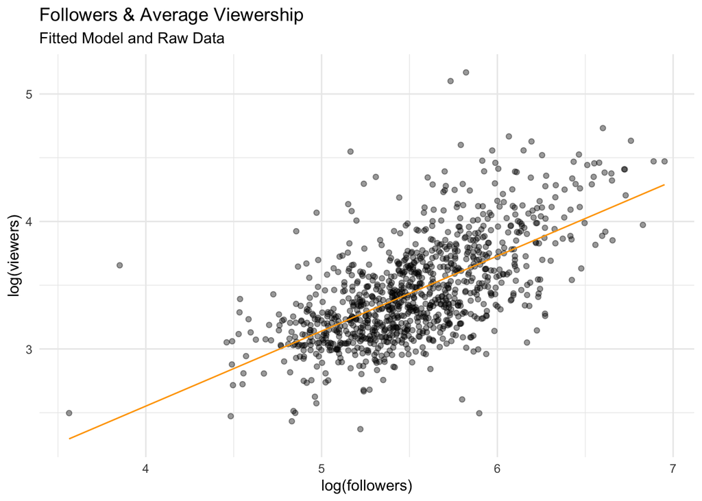

```r
pred_data %>%
  ggplot(aes(x = log_followers,
             y = log_viewers)) +
  geom_jitter(alpha = 0.4) +
  geom_line(aes(x = log_followers,
                y = .fitted),
            col = "orange") +
  theme_minimal() +
  labs(subtitle = "Fitted Model and Raw Data",
       title = "Followers & Average Viewership",
       x = "log(followers)",
       y = "log(viewers)")
```

I think our model describes the relationship between viewers and followers well. It displays the positive trend between average viewers and followers.

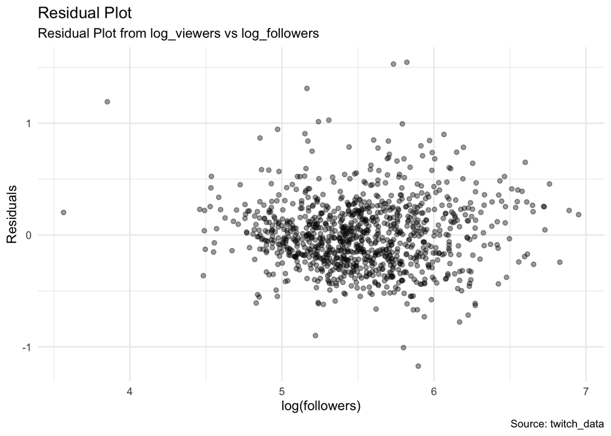

```r
pred_data |>
  ggplot(aes(x = log_followers,
             y = .resid)) +
  geom_jitter(alpha = 0.4) +
  theme_minimal() +
  labs(subtitle = "Residual Plot from log_viewers vs log_followers",
       title = "Residual Plot",
       x = "log(followers)",
       y = "Residuals",
       caption = "Source: twitch_data")
```

Above is a graph that compares log_followers and residuals. This shows the distance from each data points to the linear model. Most of our residuals are centered around 0 meaning that there is little fluctuation. There are some outliers notably the points above 1.5 and below -1.0. These large residuals do not happen that often so our linear model is a good fit for the data and can predict average viewers for the range of our followers.

## Question 4

```r
langauge <- twitch_data |>
  select(channel, language, average_viewers)
langauge
```

```
# A tibble: 1,000 × 3
   channel    language   average_viewers
   <chr>      <chr>                <dbl>
 1 xQcOW      English              27716
 2 summit1g   English              25610
 3 Gaules     Portuguese           10976
 4 ESL_CSGO   English               7714
 5 Tfue       English              29602
 6 Asmongold  English              42414
 7 NICKMERCS  English              24181
 8 Fextralife English              18985
 9 loltyler1  English              22381
10 Anomaly    English              12377
# ℹ 990 more rows
```

```r
langauge |>
  sample_n(size = 10)
```

```
# A tibble: 10 × 3
   channel        language   average_viewers
   <chr>          <chr>                <dbl>
 1 Etoiles        French                2090
 2 xTheSolutionTV German                2027
 3 Scarra         English               6060
 4 bateson87      English               3344
 5 mL7support     English               2124
 6 Jahrein        Turkish               8929
 7 Letshe         English               3073
 8 c9judite       Portuguese             644
 9 WARDELL        English               1394
10 PG_Esports     Italian               1933
```

I randomly selected 10 streamers to compare the English streamers’ average viewers to the other streamers. 5 out of the 10 streamers are English speaking, that being said, their average ratings are pretty similar compared to non-English streamers apart from 2 outliers.

Now lets summarize the data

```r
summary(langauge)
```

```
   channel            language         average_viewers
 Length:1000        Length:1000        Min.   :   235
 Class :character   Class :character   1st Qu.:  1458
 Mode  :character   Mode  :character   Median :  2425
                                       Mean   :  4781
                                       3rd Qu.:  4786
                                       Max.   :147643
```

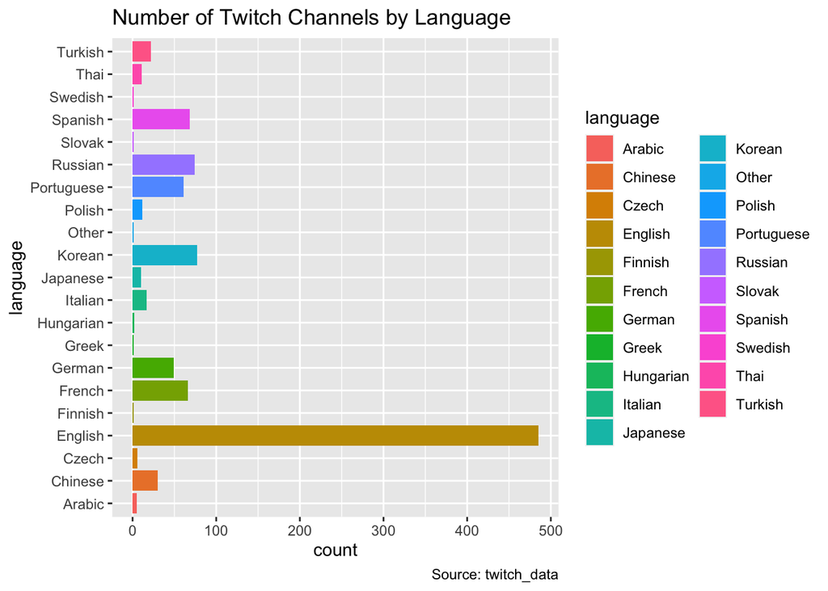

```r
ggplot(data = langauge,
       mapping = aes(x = language,
                     fill = language)) +
  geom_bar() +
  coord_flip() +
  labs(title = "Number of Twitch Channels by Language", caption = "Source: twitch_data")
```

This graph shows the number of twitch channels by language. English streamers are clearly more common compared to non-English streamers.

Now lets create a data set for English and non-English streamers.

```r
english <- langauge |>
  filter(language == "English")
english
```

```
# A tibble: 485 × 3
   channel      language average_viewers
   <chr>        <chr>              <dbl>
 1 xQcOW        English            27716
 2 summit1g     English            25610
 3 ESL_CSGO     English             7714
 4 Tfue         English            29602
 5 Asmongold    English            42414
 6 NICKMERCS    English            24181
 7 Fextralife   English            18985
 8 loltyler1    English            22381
 9 Anomaly      English            12377
10 TimTheTatman English            25664
# ℹ 475 more rows
```

```r
summary(english)
```

```
   channel            language         average_viewers
 Length:485         Length:485         Min.   :   235
 Class :character   Class :character   1st Qu.:  1458
 Mode  :character   Mode  :character   Median :  2483
                                       Mean   :  5113
                                       3rd Qu.:  5001
                                       Max.   :147643
```

```r
non_english <- langauge |>
  filter(language != "English")
non_english
```

```
# A tibble: 515 × 3
   channel               language   average_viewers
   <chr>                 <chr>                <dbl>
 1 Gaules                Portuguese           10976
 2 Rubius                Spanish              42948
 3 auronplay             Spanish              53986
 4 MontanaBlack88        German               33514
 5 풍월량 (hanryang1125) Korean               12201
 6 alanzoka              Portuguese           19560
 7 LCK_Korea             Korean               39848
 8 TheRealKnossi         German               24595
 9 TheGrefg              Spanish              28887
10 YoDa                  Portuguese           12868
# ℹ 505 more rows
```

```r
summary(non_english)
```

```
   channel            language         average_viewers
 Length:515         Length:515         Min.   :   271
 Class :character   Class :character   1st Qu.:  1453
 Mode  :character   Mode  :character   Median :  2403
                                       Mean   :  4469
                                       3rd Qu.:  4604
                                       Max.   :126232
```

The English streamers have a mean of 5113 average viewers while the non-English streamers have a mean of 4469 average viewers.

Now, lets visuealize the data by comparing average viewers to language.

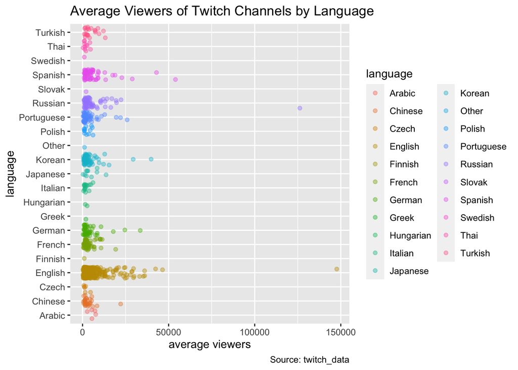

```r
ggplot(data = langauge,
       mapping = aes(x = language, y = average_viewers, color = language)) +
  geom_jitter(alpha = 0.4) +
  coord_flip() +
  labs(title = "Average Viewers of Twitch Channels by Language", x = "language", y = "average viewers", caption = "Source: twitch_data")
```

## Question 5

```r
langauge <- twitch_data %>%
  mutate(language = as.factor(language),
         language = relevel(language, ref = "English"))
```

```r
fit_lang <- lm(average_viewers ~ language,
           data = langauge)

broom::tidy(fit_lang)
```

```
# A tibble: 21 × 5
   term              estimate std.error statistic  p.value
   <chr>                <dbl>     <dbl>     <dbl>    <dbl>
 1 (Intercept)          5113.      385.    13.3   3.47e-37
 2 languageArabic        569.     3808.     0.150 8.81e- 1
 3 languageChinese     -1688.     1594.    -1.06  2.90e- 1
 4 languageCzech       -3285.     3480.    -0.944 3.45e- 1
 5 languageFinnish     -4086.     8480.    -0.482 6.30e- 1
 6 languageFrench      -1606.     1111.    -1.45  1.49e- 1
 7 languageGerman       -835.     1270.    -0.657 5.11e- 1
 8 languageGreek       -3152.     8480.    -0.372 7.10e- 1
 9 languageHungarian   -2972.     6002.    -0.495 6.21e- 1
10 languageItalian     -2907.     2090.    -1.39  1.65e- 1
# ℹ 11 more rows
```

```r
fit_lang
```

```
Call:
lm(formula = average_viewers ~ language, data = langauge)

Coefficients:
       (Intercept)      languageArabic     languageChinese       languageCzech
            5112.8               569.4             -1688.0             -3285.1
   languageFinnish      languageFrench      languageGerman       languageGreek
           -4085.8             -1606.3              -834.6             -3151.8
 languageHungarian     languageItalian    languageJapanese      languageKorean
           -2972.3             -2907.3              -350.2             -1198.9
     languageOther      languagePolish  languagePortuguese     languageRussian
           -3963.8             -2207.6             -1311.9              1481.4
    languageSlovak     languageSpanish     languageSwedish        languageThai
           -3040.8              1336.9             -4085.8             -3101.5
   languageTurkish
            -352.0
```

```r
twitch_data |>
  summarize(standard_deviation = sd(average_viewers, na.rm = TRUE))
```

```
# A tibble: 1 × 1
  standard_deviation
               <dbl>
1              8454.
```

Fitting the model allows us to look at different coefficients for each language and compare their average viewers compared to English. There are a greater number of negative coefficient meaning that most languages have less average viewers compared to English. This helps prove our initial prediction that English streamers have more viewers.

The standard deviation of average viewers is about 8500 average viewers. The coefficients are less than one standard deviation of the actual data which tells us that the fitted model is a good prediction of the data.

There are 3 languages that have more average viewers than English which are Spanish, Russian, and Arabic.

## Question 6

```r
library(broom)

Q6 <- augment(fit_lang)

# glimpse our new data
glimpse(Q6)
```

```
Rows: 1,000
Columns: 8
$ average_viewers <dbl> 27716, 25610, 10976, 7714, 29602, 42414, 24181, 18985,…
$ language        <fct> English, English, Portuguese, English, English, Englis…
$ .fitted         <dbl> 5112.814, 5112.814, 3800.934, 5112.814, 5112.814, 5112…
$ .resid          <dbl> 22603.186, 20497.186, 7175.066, 2601.186, 24489.186, 3…
$ .hat            <dbl> 0.002061856, 0.002061856, 0.016393443, 0.002061856, 0.…
$ .sigma          <dbl> 8444.313, 8449.818, 8472.094, 8474.843, 8438.923, 8390…
$ .cooksd         <dbl> 7.019555e-04, 5.772431e-04, 5.788931e-04, 9.296361e-06…
$ .std.resid      <dbl> 2.6710814, 2.4222095, 0.8540523, 0.3073893, 2.8939553,…
```

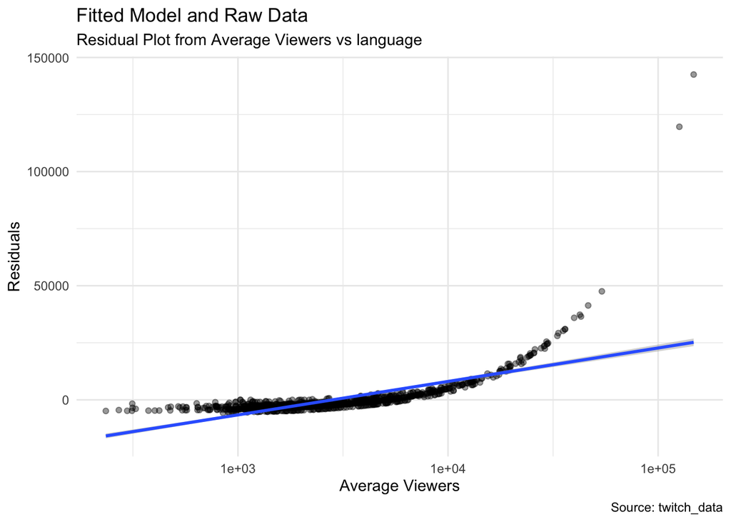

```r
ggplot(Q6,
       aes(x = average_viewers,
           y = .resid)) +
  geom_jitter(alpha = 0.4) +
  geom_smooth(method = lm) +
  theme_minimal() +
  labs(subtitle = "Residual Plot from Average Viewers vs language",
       title = "Fitted Model and Raw Data",
       x = "Average Viewers",
       y = "Residuals",
       caption = "Source: twitch_data") +
  scale_x_log10()
```